# 1. Biasand Variance Decomposition for the l2-regularized Mean Estimator

## 1.a

$$h_{avg}(D) \leftarrow argmin_{m \in R} \frac{1}{n}\sum_{i=1}^n|Y_i - m|^2$$ To find the minimun of $\frac{1}{n}\sum_{i=1}^n|Y_i - m|^2$ with respect to m, $$\frac{d}{dm}(\frac{1}{n}\sum_{i=1}^n|Y_i - m|^2)$$ We can calculate $$\frac{d}{dm}(Y_i-m)^2$$ $$=-2(Y_i-m)$$ So $$\frac{d}{dm}(\frac{1}{n}\sum_{i=1}^n|Y_i - m|^2)$$ $$=\frac{1}{n}\sum_{i=1}^n(-2)(Y_i-m)$$ $$=-\frac{2}{n}\sum_{i=1}^n(Y_i-m)$$ And the minimum is $$-\frac{2}{n}\sum_{i=1}^n(Y_i-m) = 0$$ $$\sum_{i=1}^n(Y_i-m) = 0$$ $$\sum_{i=1}^nY_i-nm = 0$$ $$\sum_{i=1}^nY_i = nm $$ $$\therefore m = \frac{1}{n}\sum_{i=1}^nY_i$$ Which is the sample average estimator $$h_{avg} = \frac{1}{n}\sum_{i=1}^nY_i$$ .

## 1.b

### Bias:

$$|E_D[h_{avg}(D)]-\mu|^2$$ $$=|E[\frac{1}{n}\sum_{i=1}^nY_i]-\mu|^2$$ $$=|\frac{1}{n}\sum_{i=1}^nE[Y_i]-\mu|^2$$ Since $E[Y] = \mu$, $$=|\frac{1}{n}\sum_{i=1}^n\mu-\mu|^2$$ $$=|\frac{n\mu}{n}-\mu|^2$$ $$=0$$ .

### Variance:

$$E_D[|h_{avg}(D)-E_D[h_{avg}(D)]|^2]$$ $$=E[|\frac{1}{n}\sum_{i=1}^nY_i-E[\frac{1}{n}\sum_{i=1}^nY_i]|^2]$$ $$=E[|\frac{1}{n}\sum_{i=1}^nY_i-\frac{1}{n}\sum_{i=1}^nE[Y_i]|^2]$$ $$=E[(\frac{1}{n}\sum_{i=1}^n(Y_i-E[Y_i]))^2]$$ $$=E[(\frac{1}{n}\sum_{i=1}^n(Y_i-\mu))^2]$$ $$=\frac{1}{n^2}\sum_{i=1}^nE[(Y_i-\mu)^2]$$ Since $E[(Y-\mu)^2] = \sigma^2$, $$=\frac{1}{n^2}\sum_{i=1}^n\sigma^2$$ $$=\frac{n\sigma^2}{n^2}$$ $$=\frac{\sigma^2}{n}$$ .

## 1.c

$$h_\lambda(D) \leftarrow argmin_{m\in R}\frac{1}{n}\sum_{i=1}^n|Y_i-m|^2+\lambda|m|^2$$ We need to solve $$\frac{d}{dm}\frac{1}{n}\sum_{i=1}^n|Y_i-m|^2+\lambda|m|^2 = 0$$ For the first term, we have solved in 1.a: $$-\frac{2}{n}\sum_{i=1}^n(Y_i-m)$$ $$=-\frac{2\sum_{i=1}^nY_i}{n}+2m$$ For the second term: $$\frac{d}{dm}\lambda m^2$$ $$=2\lambda m$$ So $$-\frac{2\sum_{i=1}^nY_i}{n}+2m + 2\lambda m = 0$$ $$m+\lambda m = \frac{\sum_{i=1}^nY_i}{n}$$ $$m(\lambda+1) = h_{avg}$$ $$m = \frac{h_{avg}}{\lambda+1}$$ $$\therefore h_\lambda (D)= \frac{h_{avg}}{\lambda+1}$$ .

## 1.d

### Bias:

$$|E_D[h_\lambda(D)]-\mu|^2$$ $$=|E[\frac{h_{avg}}{\lambda+1}]-\mu|^2$$ From 1.b we know that $E[h_{avg}] = E[\frac{1}{n}\sum_{i=1}^nY_i] = \mu$
Which means $$=(\frac{1}{\lambda+1}\mu-\mu)^2$$ $$=(\frac{-\mu\lambda}{\lambda+1})^2$$ .

### Variance:

$$E_D[|h_{\lambda}(D)-E_D[h_{\lambda}(D)]|^2]$$

- $h_\lambda(D) = \frac{h_{avg}}{\lambda+1} = \frac{\sum_{i=1}^nY_i}{n\lambda+n}$ $$=E[|\frac{\sum_{i=1}^nY_i}{n\lambda+n}-E[\frac{\sum_{i=1}^nY_i}{n\lambda+n}]|^2]$$ $$=E[|\frac{\sum_{i=1}^nY_i}{n\lambda+n}-\frac{\sum_{i=1}^n}{n\lambda+n}E[Y_i]|^2]$$ $$=E[|\frac{\sum_{i=1}^nY_i}{n\lambda+n}-\frac{\sum_{i=1}^n}{n\lambda+n}\mu|^2]$$ $$=E[|\frac{\sum_{i=1}^n}{n\lambda+n}(Y_i-\mu)|^2]$$ $$=\frac{1}{(n\lambda+n)^2}\sum_{i=1}^nE[(Y_i-\mu)^2]$$ $$=\frac{1}{(n\lambda+n)^2}\sum_{i=1}^n\sigma^2$$ $$=\frac{n\sigma^2}{(n\lambda+n)^2}$$ $$=\frac{n\sigma^2}{n^2(\lambda+1)^2}$$ $$=\frac{\sigma^2}{n(\lambda+1)^2}$$ .

## 1.e

```python
import matplotlib.pyplot as plt
%matplotlib inline
import numpy as np
```

```python
def calc_bias(mu, lam):
    return ((-mu*lam)/(lam+1))**2

def calc_var(var, lam, n):
    return var/(n*(lam+1)**2)

def calc_decomp(mu, lam, n):
    return calc_bias(mu, lam, n)+calc_var(mu, lam, n)

def plot_bv_decomp(mu, var, n, lams):
    biases = np.array([calc_bias(mu,lam) for lam in lams])
    vars = np.array([calc_var(var, lam, n) for lam in lams])
    decomps = biases + vars
    plt.plot(lams, biases, label='bias')
    plt.plot(lams, vars, label='variance')
    plt.plot(lams, decomps, label='squared error')
    plt.legend()
    plt.xlabel('lambda')
    plt.ylabel('value')
    plt.show()
```

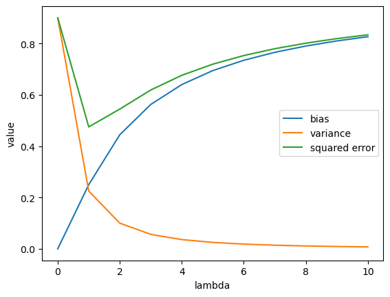

```python
# example with mu = 1, var = 9, n = 10
plot_bv_decomp(mu=1, var=9, n=10, lams=np.arange(0,11))
```

## 1.f

- The graph shows that when lambda increases, bias increases and variance decreases.
- The summation of them (i.e. the expected squared error), in this specific scenario (with parameters mu = 1, variance = 9, n = 10),
  - It dips at first, with the minimum occurring around lambda = 1.
  - it then gradually increases as lambda continues to grow.
- As lambda becomes arbitrarily large, the variance approaches 0, and as a result, the expected squared error approximates the bias.

```python
# check other values
# plot_bv_decomp(mu=1, var=9, n=10, lams=np.arange(1,20))
```

# 2. Different Flavours of Regression

## 2.a

We have the Poisson distribution $$p(Z_i;\lambda)=\frac{\lambda^ke^{-\lambda}}{Z_i!}$$ and the MLE $$MLE = \argmax_\lambda \log\Pi_{i=1}^N p(Z_i;\lambda)$$ Assuming that $Z_i$ is identically and independentaly distributed (i.i.d.).

- $P(Z_1,Z_2,...,Z_N) = P(Z_1)*P(Z_2)*...*P(Z_N)$

First we calculate the log likelihood function: $$\log\Pi_{i=1}^N p(Z_i;\lambda)$$ $$=\sum_{i=1}^N\log \frac{\lambda^ke^{-\lambda}}{Z_i!}$$ $$=\sum_{i=1}^N (Z_i\log\lambda - \lambda \log e - \log(Z_i!))$$ $$=\sum_{i=1}^N (Z_i\log\lambda - \lambda - \log(Z_i!))$$ To find the MLE,
$$\frac{d}{d\lambda} \sum_{i=1}^N (Z_i\log\lambda - \lambda - \log(Z_i!)) = 0$$ $$\sum_{i=1}^N \frac{d}{d\lambda} (Z_i\log\lambda - \lambda - \log(Z_i!)) = 0$$ $$\sum_{i=1}^N (\frac{Z_i}{\lambda}-1) = 0$$ $$\frac{1}{\lambda}\sum_{i=1}^N Z_i - N = 0$$ $$\frac{1}{\lambda}\sum_{i=1}^N Z_i = N$$ $$\lambda = \frac{1}{N}\sum_{i=1}^NZ_i$$ $$\therefore \lambda_{MLE} = \frac{1}{N}\sum_{i=1}^NZ_i$$ .

## 2.b

$$p(y|x;w)=\frac{e^{yw^Tx}\cdot e^{-e^{w^Tx}}}{y!}$$ For $\{(x^{(1)},y^{(1)}),...,(x^{(N)},y^{(N)})\}$ and assuming they are i.i.d., the log lokelihood is $$log\Pi_{i=1}^N \frac{e^{y^{(i)}wx^{(i)}\cdot e^{-e^{wx^{(i)}}}}}{y^{(i)}!}$$ $$=\sum_{i=1}^N log(\frac{e^{y^{(i)}wx^{(i)}}\cdot e^{-e^{wx^{(i)}}}}{y^{(i)}!})$$ $$=\sum_{i=1}^N (y^{(i)}wx^{(i)} - e^{wx^{(i)}} - log(y^{(i)}!))$$ So the maximum likelihood function would be $$\argmax_w \sum_{i=1}^N (y^{(i)}wx^{(i)} - e^{wx^{(i)}} - log(y^{(i)}!))$$ .

## 2.c

If we write $$ \frac{1}{2}\sum_{i=1}N a_i^{(i)} (y^{(i)}-w^Tx^{(i)})^2$$ into the matrix notation, we will have $$\frac{1}{2}(y-Xw)^TTA(y-Xw)$$ $$=\frac{1}{2}(y^TAy-2y^TAXw+w^TX^TAXw)$$ . And we will need to compute the gradient of it: $$\frac{\partial}{\partial w}\frac{1}{2}(y^TAy-2y^TAXw+w^TX^TAXw) = 0$$

- the first term $y^TAy$ does not depend on w, which means the derivative w.r.t. w is 0 $$-X^TAy + X^TAXw = 0$$ $$X^TAXw = X^TAy$$ $$\therefore w = (X^TAX)^{-1}X^TAy$$ .

## 2.d

As the temperature $\tau \rightarrow 0$:

- the denominator inside the exponent approaches 0
- for those training points who are very close to the query point (the numerator inside the exponent approaches 0), we will have exponents that are close to 0
- in this case, the weight (ai, without normalizing) will be close to 1
- this leads to a very localised weighting, which causes overfitting.

On the other hand, as the temperature tau approaches infinity:

- the denominator of the exponent approaches infinity
- in this case the numerator has minimal effect
- so all the weights (ai) will be similar.
- this leads to a uniform weighting, which essentially is the linear model instead of a 'locally' weighted regression.

The computational complexity of the locally weighted regression is significantly greater than the least square regression, which can be seen in the problem below (3.2.e and .f). The reason is that we need to compute the matrix A of a query point (a row from the test set) with regard to the entire training set. For example, if our training set has N=10000 observation (what we have in question 3), the dimension of matrix A would be (N*N) = (10000*10000). While it only has entries diagonally (i.e. 10000 entries for A from question 3), we also need to know that for each entry, we need to do feature-pair-wise distance calculation (in question 3, after one hot encoded, there are P = 52 feature columns). And don't forget we are asked to use at least 200 query points from the test set. That's A LOT of calculation, which is a significant disadvantage compared to OLS, where we can have a fitted model based on the training set and simply use it to predict the test set.

# 3. Implementing Regression Methods in Python

## 3.1. Initial Data Analysis

```python
import sys
import time
import warnings
warnings.simplefilter(action='ignore', category=FutureWarning)

import pandas as pd
import seaborn as sns
import autograd
from IPython.display import HTML

import mglearn
from IPython.display import display

from sklearn.utils import shuffle
from sklearn.pipeline import Pipeline, make_pipeline
from sklearn.compose import ColumnTransformer, make_column_transformer
from sklearn.feature_extraction.text import CountVectorizer
from sklearn.model_selection import cross_val_score, cross_validate, train_test_split
from sklearn.metrics import accuracy_score, r2_score
from sklearn.neighbors import KNeighborsClassifier, KNeighborsRegressor
from sklearn.tree import DecisionTreeClassifier, plot_tree

pd.set_option("display.max_colwidth", 200)
```

```python
# 3.1.a
df_hour = pd.read_csv('bike+sharing+dataset/hour.csv', index_col=0)
df_hour.head()
```

| instant | dteday | season | yr | mnth | hr | holiday | weekday | workingday | weathersit | temp | atemp | hum | windspeed | casual | registered | cnt |
| --- | --- | --- | --- | --- | --- | --- | --- | --- | --- | --- | --- | --- | --- | --- | --- | --- |
| 1 | 2011-01-01 | 1 | 0 | 1 | 0 | 0 | 6 | 0 | 1 | 0.24 | 0.2879 | 0.81 | 0.0 | 3 | 13 | 16 |
| 2 | 2011-01-01 | 1 | 0 | 1 | 1 | 0 | 6 | 0 | 1 | 0.22 | 0.2727 | 0.80 | 0.0 | 8 | 32 | 40 |
| 3 | 2011-01-01 | 1 | 0 | 1 | 2 | 0 | 6 | 0 | 1 | 0.22 | 0.2727 | 0.80 | 0.0 | 5 | 27 | 32 |
| 4 | 2011-01-01 | 1 | 0 | 1 | 3 | 0 | 6 | 0 | 1 | 0.24 | 0.2879 | 0.75 | 0.0 | 3 | 10 | 13 |
| 5 | 2011-01-01 | 1 | 0 | 1 | 4 | 0 | 6 | 0 | 1 | 0.24 | 0.2879 | 0.75 | 0.0 | 0 | 1 | 1 |

```python
# 3.1.b
df_hour['dteday'] = pd.to_datetime(df_hour['dteday'], format='%Y-%m-%d')
print(f'number of data points: {df_hour.shape[0]}\n')
print(f'dimensions: {df_hour.shape[1]}\n')
print(f'used data types:')
print(df_hour.dtypes)
```

```
number of data points: 17379

dimensions: 16

used data types:
dteday        datetime64[ns]
season                 int64
yr                     int64
mnth                   int64
hr                     int64
holiday                int64
weekday                int64
workingday             int64
weathersit             int64
temp                 float64
atemp                float64
hum                  float64
windspeed            float64
casual                 int64
registered             int64
cnt                    int64
dtype: object
```

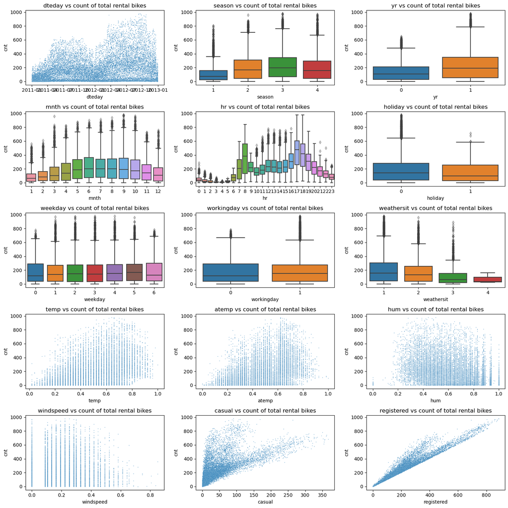

```python
# 3.1.c
feats = df_hour.drop(columns=['cnt']).columns

fig, axs = plt.subplots(nrows=5,ncols=3, figsize=(15,15))

axs = axs.flatten()
for i, f in enumerate(feats):
    if f in ['dteday','casual','registered','temp','atemp','hum','windspeed']:
        sns.scatterplot(data=df_hour, x=f, y='cnt', ax=axs[i], s=1)
    else:
        sns.boxplot(data=df_hour, x=f, y='cnt', ax=axs[i], flierprops={'alpha':0.3,'markersize':5})
        # sns.scatterplot(data=df_hour, x=f, y='cnt', ax=axs[i], s = 1)
    axs[i].set_title(f'{f} vs count of total rental bikes')

plt.tight_layout()
plt.show()
```

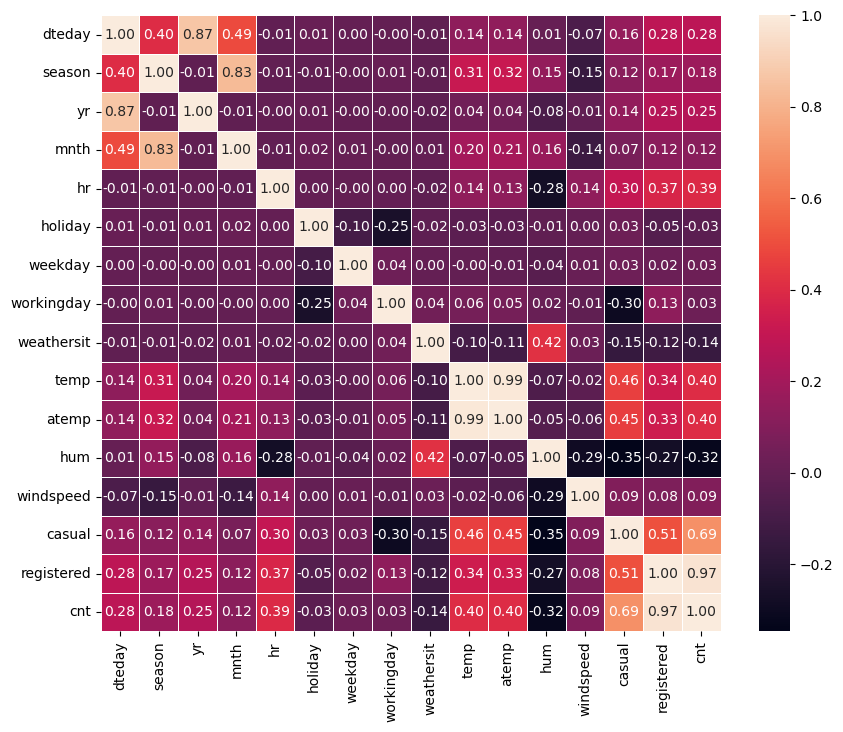

```python
# 3.1.d
corr_matrix = df_hour.corr()
plt.figure(figsize=(10,8))
sns.heatmap(corr_matrix, annot=True, fmt='.2f', linewidths=0.5)
plt.show()
```

```python
print('most positively correlated with target (cnt): temp and atemp')
print('temp: normalized temperature (Celsius); atemp: normalized feeling temperature (Celsius)\n')
print('most neegatively correlated with target (cnt): hum (normalized humidity)\n')
print('least correlated with target (cnt): holiday, weekday, working day')
```

```
most positively correlated with target (cnt): temp and atemp
temp: normalized temperature (Celsius); atemp: normalized feeling temperature (Celsius)

most neegatively correlated with target (cnt): hum (normalized humidity)

least correlated with target (cnt): holiday, weekday, working day
```

```python
# 3.1.e
# column 'instant' has been assigned as index when loading the data
df_hour_dropcol= df_hour.drop(columns=['atemp', 'registered', 'casual', 'dteday']).reset_index(drop=True)
df_hour_dropcol.head()
```

|  | season | yr | mnth | hr | holiday | weekday | workingday | weathersit | temp | hum | windspeed | cnt |
| --- | --- | --- | --- | --- | --- | --- | --- | --- | --- | --- | --- | --- |
| 0 | 1 | 0 | 1 | 0 | 0 | 6 | 0 | 1 | 0.24 | 0.81 | 0.0 | 16 |
| 1 | 1 | 0 | 1 | 1 | 0 | 6 | 0 | 1 | 0.22 | 0.80 | 0.0 | 40 |
| 2 | 1 | 0 | 1 | 2 | 0 | 6 | 0 | 1 | 0.22 | 0.80 | 0.0 | 32 |
| 3 | 1 | 0 | 1 | 3 | 0 | 6 | 0 | 1 | 0.24 | 0.75 | 0.0 | 13 |
| 4 | 1 | 0 | 1 | 4 | 0 | 6 | 0 | 1 | 0.24 | 0.75 | 0.0 | 1 |

```python
# 3.1.f
df_hour_shuffled = shuffle(df_hour_dropcol, random_state=0)
df_train = df_hour_shuffled.iloc[:10000]
df_test = df_hour_shuffled.iloc[10000:]

# double check
print(df_train.shape)
df_train.head()
```

```
(10000, 12)
```

|  | season | yr | mnth | hr | holiday | weekday | workingday | weathersit | temp | hum | windspeed | cnt |
| --- | --- | --- | --- | --- | --- | --- | --- | --- | --- | --- | --- | --- |
| 3439 | 2 | 0 | 5 | 5 | 0 | 6 | 0 | 1 | 0.56 | 0.88 | 0.2239 | 7 |
| 6542 | 4 | 0 | 10 | 4 | 0 | 3 | 1 | 1 | 0.44 | 0.88 | 0.0000 | 5 |
| 15470 | 4 | 1 | 10 | 19 | 0 | 4 | 1 | 1 | 0.44 | 0.51 | 0.1343 | 743 |
| 9851 | 1 | 1 | 2 | 11 | 1 | 1 | 0 | 1 | 0.26 | 0.48 | 0.3582 | 208 |
| 12640 | 2 | 1 | 6 | 21 | 0 | 5 | 1 | 1 | 0.66 | 0.50 | 0.1045 | 333 |

## 3.2. Regression Implementations

```python
# 3.2.a
# OLS: w = (X^T @ X)^-1 @ X^T @ t
# X is X_train
# t is y_train

# X and t should be np arrays
# use .values for a pandas dataframe
def get_ols_w(X,t):
    return np.linalg.inv(X.T @ X) @ X.T @ t

X_train = df_train.drop(columns=['cnt'])
# X_train.shape
y_train = df_train['cnt']
# y_train.shape

X_test = df_test.drop(columns=['cnt'])
y_test = df_test['cnt']


# ols weight for the first part
ols_w_1 = get_ols_w(X_train.values, y_train.values)
# ols_w_1.shape
```

```python
# 3.2.b

# same thing, X and w are both bp arrays
def ols_pred(X,w):
    return X @ w
pred_1 = ols_pred(X_test.values,ols_w_1)
# pred_1.shape

r2_1 = r2_score(y_test, pred_1)
r2_1
```

```
0.3766194837192155
```

```python
# 3.2.c
X_train_ohe = pd.get_dummies(X_train, columns=['season', 'mnth', 'hr', 'weekday', 'weathersit'], drop_first=True).astype(int)
X_test_ohe = pd.get_dummies(X_test, columns=['season', 'mnth', 'hr', 'weekday', 'weathersit'], drop_first=True).astype(int)

X_train_ohe.head()
```

|  | yr | holiday | workingday | temp | hum | windspeed | season_2 | season_3 | season_4 | mnth_2 | ... | hr_23 | weekday_1 | weekday_2 | weekday_3 | weekday_4 | weekday_5 | weekday_6 | weathersit_2 | weathersit_3 | weathersit_4 |
| --- | --- | --- | --- | --- | --- | --- | --- | --- | --- | --- | --- | --- | --- | --- | --- | --- | --- | --- | --- | --- | --- |
| 3439 | 0 | 0 | 0 | 0 | 0 | 0 | 1 | 0 | 0 | 0 | ... | 0 | 0 | 0 | 0 | 0 | 0 | 1 | 0 | 0 | 0 |
| 6542 | 0 | 0 | 1 | 0 | 0 | 0 | 0 | 0 | 1 | 0 | ... | 0 | 0 | 0 | 1 | 0 | 0 | 0 | 0 | 0 | 0 |
| 15470 | 1 | 0 | 1 | 0 | 0 | 0 | 0 | 0 | 1 | 0 | ... | 0 | 0 | 0 | 0 | 1 | 0 | 0 | 0 | 0 | 0 |
| 9851 | 1 | 1 | 0 | 0 | 0 | 0 | 0 | 0 | 0 | 1 | ... | 0 | 1 | 0 | 0 | 0 | 0 | 0 | 0 | 0 | 0 |
| 12640 | 1 | 0 | 1 | 0 | 0 | 0 | 1 | 0 | 0 | 0 | ... | 0 | 0 | 0 | 0 | 0 | 1 | 0 | 0 | 0 | 0 |

5 rows × 52 columns

```python
# 3.2.d
# first we need to check if X^TX is invertible for both X_train_ohe and X_test_ohe
# if the det is 0, that means the matrix is non invertible
det_train = np.linalg.det(X_train_ohe.values.T @ X_train_ohe.values)
det_test = np.linalg.det(X_test_ohe.values.T @ X_test_ohe.values)
det_train, det_test
```

```
(0.0, 0.0)
```

```python
# after one hot encoded, the X^X of both train and test sets are non invertible
# therefore we need to use pseudoinverse (.pinv) instead of .inv in hte get_ols_w function
def get_ols_w_pseudo(X,t):
    return np.linalg.pinv(X.T @ X) @ X.T @ t

#  this is part 2 of the 3.2 question, so the var names are appended with _2
ols_w_2 = get_ols_w_pseudo(X_train_ohe.values, y_train.values)
pred_2 = ols_pred(X_test_ohe.values, ols_w_2)
r2_2 = r2_score(y_test, pred_2)
r2_2
```

```
0.6646602791153005
```

```python
# 3.2.e
# Implement the locally weighted regression algorithm
# as described in Question 2.
# w* = (X.T A X)^-1 X.T A y
# X is the design matrix
# A is the diagonal matrix where A_ii = a^(i)
def get_w_star(X,y,query_point, tau):
    '''
    for each query point (i.e. each row in the test set), we put it into (XTAX)-1XTAy
    X: design matrix (N*P) N is #training_points; P is #features
    A: (N*N) diagonal matrix (each diagonal is the weight of this specific test point to every training point)
    y: y_train (N*1)
    '''

    N = X.shape[0]
    A = np.zeros((N,N))
    for i in range(N):
        dist = np.linalg.norm(X[i,:] - query_point) # ||x-xi||
        A[i,i] = np.exp(-dist**2 / (2*tau**2))

    # normalize A
    A = A/np.sum(A)

    # make sure y is a np array
    y = np.array(y)

    w_star = np.linalg.pinv(X.T@A@X)@X.T@A@y
    return w_star
```

```python
# 3.2.f
# with tau = 1
# note that params in np arrays, so will need to convert df with .values
# only using the first 200 samples from the test set

w_stars = [get_w_star(X_train_ohe.values,y_train.values,q,tau=1) for q in X_test_ohe.values[:200]]
# just to make sure we get everything we need
print(len(w_stars))
w_stars[0].shape
```

```
200
```

```
(52,)
```

```python
# prediction of the first 200 rows from the test set
pred_lwr = [q @ w_stars[i] for i,q in enumerate(X_test_ohe.values[:200])]
r2_lwr = r2_score(y_test[:200], pred_lwr)
r2_lwr
```

```
0.7924438053454238
```

```python
# also try tau = 0.1 and tau = 10
w_stars_smalltau = [get_w_star(X_train_ohe.values,y_train.values,q,tau=0.1) for q in X_test_ohe.values[:200]]
w_stars_bigtau = [get_w_star(X_train_ohe.values,y_train.values,q,tau=10) for q in X_test_ohe.values[:200]]
```

```python
# preds of tau = 0.1 and tau = 10
pred_lwr_smalltau = [q @ w_stars_smalltau[i] for i,q in enumerate(X_test_ohe.values[:200])]
r2_lwr_smalltau = r2_score(y_test[:200], pred_lwr_smalltau)
pred_lwr_bigtau = [q @ w_stars_bigtau[i] for i,q in enumerate(X_test_ohe.values[:200])]
r2_lwr_bigtau = r2_score(y_test[:200], pred_lwr_bigtau)

print(f'tau = 0.1, r2 = {round(r2_lwr_smalltau,3)}')
print(f'tau = 1, r2 = {round(r2_lwr,3)}')
print(f'tau = 10, r2 = {round(r2_lwr_bigtau,3)}')
```

```
tau = 0.1, r2 = 0.713
tau = 1, r2 = 0.792
tau = 10, r2 = 0.662
```

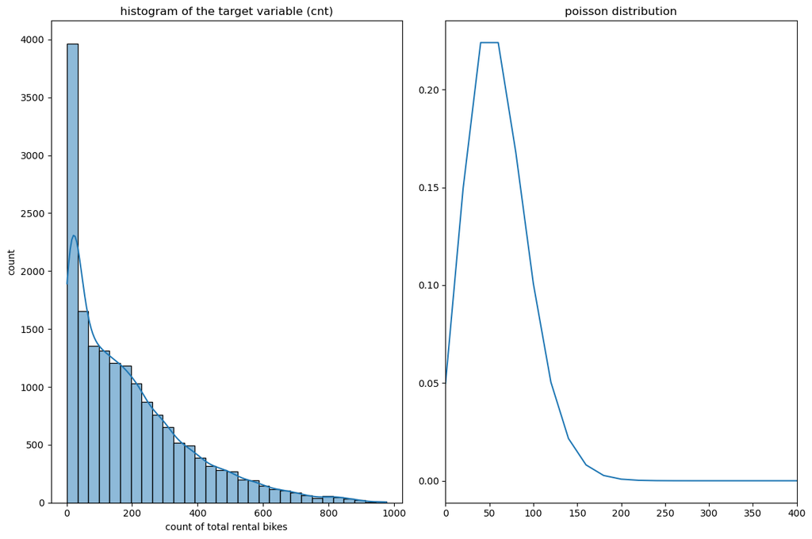

```python
# 3.2.g
from scipy.stats import poisson
fig, ax = plt.subplots(1,2,figsize=(12,8))
sns.histplot(df_hour['cnt'], bins=30, kde=True, ax=ax[0])
# plot a poisson dist curve
ax[1].plot(np.arange(0,10000),poisson.pmf(np.arange(0,10000),3))
ax[1].set_xlim(0,20)
ax[1].set_xticklabels(np.arange(0,500,50))

ax[0].set_xlabel('count of total rental bikes')
ax[0].set_ylabel('count')
ax[0].set_title('histogram of the target variable (cnt)')
ax[1].set_title('poisson distribution')
plt.tight_layout()
plt.show()
```

```python
# 3.2.h
# poisson regression
# not done
```

[output not shown]

```python
# 3.2.i
```

```python
# 3.2.j
```